# Connectiviy analysis `cola`

Find in this page the details and insrtuctions for a) installation and b) customize parameters

### A) Installation

This package integrates R and Python modules.

It’s required to install several components (once). The structure of this software is:

- R as the base. Use the latest available [here](https://cran.r-project.org/bin/windows/base/)
- Have you [Rtools](https://cran.r-project.org/bin/windows/Rtools/) already? `devtools::find_rtools()` must be TRUE
- Python as the engine for the main scripts
- Miniconda (conda) environment as the package containing all python dependencies
- R shiny for the dashboard Decision support system.

Some of the different computers might have particular conditions or requirements for installing all these components, so we made a section where you can find known issues an their potential solution. If you found a new one please share it with us so potential new users can see it.

*If you have any issue installing and setting up the software, please check the [KNOWN-ISSUES PAGE](https://github.com/connectingLandscapes/cola/blob/main/known-issues.md) for potential solutions*

## ——————

#### **1. Install cola R package.**

Consider use the **option 3 (None)** for installing new packages at the first try. If an error arises, update **all of them (option 1)**.

```
if (!require(devtools)){
   install.packages('devtools')
}
devtools::install_github('connectingLandscapes/cola') ## option 3: None
```

The installation log will shown in console:

```
Downloading GitHub repo connectingLandscapes/cola@HEAD
These packages have more recent versions available.
It is recommended to update all of them.
Which would you like to update?

 1: All
 2: CRAN packages only
 3: None

 ... (more text)

-- R CMD build -----------------------------------------------------------------------------------------------------------
v  checking for file 'C:\tempR\RtmpM1f5us\remotes11c8f5a7145\connectingLandscapes-cola-5abb74a/DESCRIPTION' (378ms)
-  preparing 'cola': (1.8s)
v  checking DESCRIPTION meta-information ...
-  checking for LF line-endings in source and make files and shell scripts
-  checking for empty or unneeded directories
     NB: this package now depends on R (>= 3.5.0)
     WARNING: Added dependency on R >= 3.5.0 because serialized objects in  serialize/load version 3 cannot be read in older versions of R.  File(s) containing such objects: 'cola/data/crs_df.rda'  'cola/data/perfomance-uper_per.rda'  WARNING: Added dependency on R >= 3.5.0 because serialized object…
-  building 'cola_0.1.0.tar.gz'

* installing *source* package 'cola' ...
** using staged installation
** R
** data
*** moving datasets to lazyload DB
** inst
** byte-compile and prepare package for lazy loading
** help
No man pages found in package  'cola'
*** installing help indices
** building package indices
** testing if installed package can be loaded from temporary location
*** arch - i386
*** arch - x64
** testing if installed package can be loaded from final location
*** arch - i386
*** arch - x64
** testing if installed package keeps a record of temporary installation path
* DONE (cola)
```

Here, the cola R package is installed. Now we need to set up A) the `conda` environment and B) the shiny the dashboard

##### **2. Setting up cola requirements:**

This might take several minutes and will show the following message once you *get all the steps installed*. But during the first time you will have a longer log. See next section.

```
library(cola)
cola::setup_cola()

  +Step 1/5: Installing & checking reticulate R package
    `reticulate` installed already!
  +Step 2/5 Installing & checking miniconda
    miniconda found at C:/Users/Admin/AppData/Local/r-miniconda!
  +Step 3/5 Installing & checking conda environment
    `cola` conda environment installed in C:\Users\Admin\AppData\Local\r-miniconda\envs\cola/python.exe
    `cola` conda environment named correctly!
    The python version is Python 3.9.19
  +Step 4/5 Installing & checking conda modules
    All required conda modules installed!
  +Step 5/5 Setting up local variables
    === Ready to connect landscapes! ===
```

**If there’s the first time installing cola you will see the following messages during the different steps:**

```
   +Step 1/5: Installing & checking reticulate R package
```

If `reticulate` R package doesn’t exists, you need to install it. A prompt asking if you want to install packages that requires compilation will appear. If you say “yes” this might take longer. You can also say “No”, but it might require update the packages at some point, depending in your current.

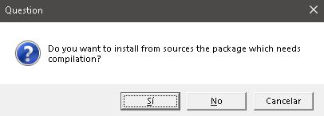

Fig. 1a. Compilation message

You might need to restart your R session as well. Say “YES”.

[figure not shown]

Fig. 1b. Compilation message

Also, you might be asked to install a reticulate conda environment. Say “YES”.

[figure not shown]

Fig. 1c. Compilation message

A correct `reticulate` R package installation will show:

```
  +Step 1/5: Installing & checking reticulate R package
    `reticulate` installed already!
```

```
  +Step 2/5 Installing & checking miniconda
```

If miniconda is not installed, you will be asked to accept the installation. Say “yes”

[figure not shown]

Fig. 2. Miniconda installation

A correct miniconda installation will show:

```
  +Step 2/5 Installing & checking miniconda
    miniconda found at C:/Users/Admin/AppData/Local/r-miniconda!
```

```
+Step 3/5 Installing & checking conda environment

+Step 4/5 Installing & checking conda modules
```

This steps creates a conda environment, named `cola` by default. You will ask to create the environment. Say “yes”

[figure not shown]

Fig. 2. Install cola conda environment

It will try several ways in the case some options doesn’t works in your machine:

```
1. Install the environment using a YML file. If fails,

2. Creating the environment with the required libraries. If fails,

3. Create the environment, and then installing each library independently
```

This step will take some minutes since requires download spatial and specialized packages.

A correct installation should shown a message like:

```
  +Step 3/5 Installing & checking conda environment

    `cola` conda environment installed in C:\Users\Admin\AppData\Local\r-miniconda\envs\cola/python.exe

    `cola` conda environment named correctly!

    The python version is Python 3.9.19

  +Step 4/5 Installing & checking conda modules

    All required conda modules installed!
```

```
  +Step 5/5 Setting up local variables
```

If all the test passed, this will be the shown:

```
  +Step 5/5 Setting up local variables
    === Ready to connect landscapes! ===
```

##### **3. Setting up cola dashboard:**

Now let’s install all the native R libraries to deply the dashboard.

```
cola::setup_cola_dss()
```

```
    === All libraries required for COLA's DSS installed ===
```

```
cola::cola_dss()
```

##### **5. Load cola and run some functions:**

```
library(cola)
input_tif <- system.file(package = 'cola', 'sampledata/sampleTif.tif')
out_shp <- 'outputPoints.shp'

simulated_points <- points_py(intif = input_tif, outshp = out_shp,
   param3 = 0 param4 =  100 param5 = 50)

if(file.exists(out_tif)){
  plot(sf::read_sf(simulated_points))
}
```

##### **6. Uninstall cola**

```
# Not run
# remove.packages( "cola" )
```

### . B) Customize `cola` parameters

There’s some parameters we can customize for `cola` performance, in each of the following parameters:

- Temporal directory `COLA_DATA_PATH`: where a folder will be created for each DSS session, and will be used to save the results. By default we use R temporal folder `tempdir()`. Keep the last slash or backshlash.
- Number of cores `COLA_NCORES`: To be used for running the programs. Default is `1`.
- Maximum size of the layer `COLA_DSS_UPL_MB`: Size to load in the shiniy dashboard in mega bytes (MB) units. Default is `250`.
- Maximum resolution for the layer representation `COLA_VIZ_THREs_PIX`, `COLA_VIZ_RES_NCOL`, `COLA_VIZ_RES_NROW`: The original layer created or uploaded will be resampled in the front end leaflet visor. This value is the upper threshold fo pixel numbers in the layer. Layers with number of pixels above this number will be resampled to `c(1000, 1000)` pixels. The default value is `1000000` for the threshold, and `1000` for the resampling size in columns and rows. Increase this number to allow your machine load bigger original files in the front end. Decrease this number to avoid loading big files in your front end.

**How to edit those variables? Don’t edit this variables unless you are an advanced user**

Find your R configuration file `.Renviron` file located in `Sys.getenv("R_USER")`. Edit with a text editor this file and edit with caution the values. Keep the proper file separator ( or /), quotes, decimal separators, etc.

```
COLA_DATA_PATH="C:\Users\USER\AppData\Local\Temp\RtmpXXXX"
COLA_NCORES=1
COLA_DSS_UPL_MB=250
COLA_VIZ_THREs_PIX=1000000
COLA_VIZ_RES_NCOL=1000
COLA_VIZ_RES_NROW=1000
```

You should also see `COLA_PYTHON_PATH` and `COLA_SCRIPTS_PATH`, but *DON’T* edit them manually.

This file is reset to the default values every time you run `cola::setup_cola()`.

[output not shown]

### . C) `cola` functions

`cola` contains the following functions: * A. Habitat suitability (HS) to surface resistance (SR) * B. Create source points * C. Cost distance matrix * D. Least corridors paths * E. Cumulative resistance dispersal kernels * F. Priorization * H. CDPOP – soon * G. Landscape genetics – soon

##### **A. Habitat suitability (HS) to surface resistance (SR)**

Converts a a given raster into a new given transformation function and outputs a numeric range.

**Python file:** s2res.py

**Parameters:** [A] py: Python executable path or instruction R runs in console to call cola python. [B] src: Python script path [1] initif: Habitat Suitability (HS) georreferenced TIF raster [2] outif: Surface resistance (SR) output file name TIF raster [3] param3: Suitability grid min value. Numeric value to cutoff the original layer. [4] param4: Suitability grid max value. Numeric value to cutoff the original layer. [5] param5: Maximum resistance value to have the new raster. Min value is set to 1. [6] param6: Shape Parameter. Between 1 and X [7] param7: No data value of suitability raster. Default NULL. To be guessed from metadata if not provided [8] param8: CRS if using ASCII|RSG or other file without projection info. Provide as EPSG or ESRI string e.g. “ESRI:102028”

**Usage in R:**

```
library(cola)
input_tif <- system.file(package = 'cola', 'sampledata/sampleTif.tif')
out_tif <- 'outputsurfaceresistance.tif'

surface_resistance <- s2res_py(intif = input_tif, outtif = out_tif,
   param3 = 0
   param4 =  100
   param5 = 100
   param6 = 1)

if(file.exists(out_tif)){
  terra::plot(terra::rast(out_tif))
}
```

**Usage in console:**

```
# Windows:
C:\Users\USER\AppData\Local\r-miniconda\envs\cola\python.exe s2res.py myhabitatsuitability.tif outputsurfaceresistance.tif 0 100 100 1

# Linux:
/home/user/anaconda3/envs/cola/bin/python s2res.py myhabitatsuitability.tif outputsurfaceresistance.tif 0 100 100 1
```

**Creates:** *outputsurfaceresistance.tif*, a raster layer with a minimum value of 1 and maximum value given the parameter [5]

##### **B. Simulate source points**

**Python file:** create_source_points.py

**Parameters:** [A] py: Python executable path or instruction R runs in console to call cola python. [B] src: Python script path [1] initif: Reference georreferenced TIF raster layer [2] outshp: Vectorial output layer [3] param3: Minimum value to mask the raster layer [4] param4: Maximun value to mask the raster layer [5] param5: Number of source points to create [6] param6: CRS if using ASCII|RSG or other file without projection info. Provide as EPSG or ESRI string e.g. “ESRI:102028”

**Usage in R:**

```
library(cola)
input_tif <- system.file(package = 'cola', 'sampledata/sampleTif.tif')
out_shp <- 'outputPoints.shp'

simulated_points <- points_py(intif = input_tif, outshp = out_shp,
   param3 = 0 param4 =  100 param5 = 50)

if(file.exists(out_tif)){
  plot(sf::read_sf(simulated_points))
}
```

**Usage in console:**

```
# Windows:
C:\Users\USER\AppData\Local\r-miniconda\envs\cola\python.exe create_source_points.py sampleTif.tif outputPoints.shp 0 100 50

# Linux:
/home/user/anaconda3/envs/cola/bin/python create_source_points.py sampleTif.tif outputPoints.shp 0 100 50
```

**Common errors:**

##### **C. Cost distance matrix**

Creates a two way interaction matrix path from a set of points and a surface resistance raster layer

**Python file:** create_cdmat.py

**Parameters:** [A] py: Python executable path or instruction R runs in console to call cola python. [B] src: Python script path [1] inshp: Vectorial layer with points file path [2] initif: Georreferenced TIF raster file path [3] outcsv: Resulting two-way matrix output file path [4] param4: Distance threshold (in cost distance units) [5] param5: Number of processors. Default is one (1) [6] param6: User provided CRS if using ASCII|RSG or other file without projection info. Provide as EPSG or ESRI string e.g. “ESRI:102028”. Default ‘None’

**Usage in R:**

```
library(cola)
input_tif <- system.file(package = 'cola', 'sampledata/sampleTif.tif')
input_shp <- system.file(package = 'cola', 'sampledata/SourcePoints_50.shp')
out_csv <- 'outputCSVmatrix.csv'

out_matrix <- cdmat_py(inshp = input_shp, intif = input_tif,
 outcsv = out_csv, param3 = 25000)

if(file.exists(out_matrix)){
  head(read.csv(out_matrix))
}
```

**Usage in console:**

[output not shown]

**Creates:** *outputCSVmatrix.csv*, a CSV two-way matrix file with the cumulative resistance among each pair of points that occurs below param4

##### **D. Least cost corridor paths (LCC)**

Creates a continuous raster with the cumulative corridor (distance * value) bewteen the points

**Python file:** lcc.py and lcc_heavy.py for bigger rasters

**Parameters:** [A] py: Python executable path or instruction R runs in console to call cola python. [B] src: Python script path [1] inshp: Spatial source point layer (any ORG driver), CSV (X, Y files), or *.xy file [2] initif: Habitat Suitability (HS) georreferenced TIF raster [3] outif: Least cost path corridors (LCC) output file name TIF raster [4] param4: Distance threshold to connect points. It should be in map distane units (such as meters) [5] param5: Corridor radius smoothing factor in number of cells. [6] param6: Corridor tolerance in cost distance units. This is the amount to add to the least cost path to create least cost corridors (should be in meters) [7] param7: Number of cores. Default is one (1) [8] param8: CRS if using ASCII|RSG or other file without projection info. Provide as EPSG or ESRI string e.g. “ESRI:102028”

**Usage in R:**

```
library(cola)
input_shp <- system.file(package = 'cola', 'sampledata/SourcePoints_50.shp')
input_tif <- system.file(package = 'cola', 'sampledata/sampleTif.tif')
out_tif <- 'outputcorridors.tif'


# Use lcc_py( ) or lccHeavy_py( ) in the same way
corridors <- lcc_py( inshp = input_shp, intif = input_tif, outtif = out_tif,
   param4 =  25000
   param5 = 100
   param6 = 5000)

if(file.exists(corridors$file)){
  terra::plot(terra::rast(corridors$file))
}
```

**Usage in console:**

```
# use lcc.py or lcc_heavy.py

# Windows:
C:\Users\USER\AppData\Local\r-miniconda\envs\cola\python.exe lcc.py SourcePoints_50.shp  myhabitatsuitability.tif outputcorridors.tif 25000 5 5

# Linux:
/home/user/anaconda3/envs/cola/bin/python lcc.py SourcePoints_50.shp  myhabitatsuitability.tif outputcorridors.tif 25000 5 5
```

**Creates:** *outputcorridors.tif*, a raster layer with continuous values of cumulative resistance between points that fail below distance threshold

**Common errors:** Raster has no define NODATA values Raster has no or uncommon projection Raster has no squared pixels Raster has multiple bands

##### **E. Create connectivity dispersal resistance kernels (CRK)**

Creates a continuous raster with the cumulative resistance kernels arround points

**Python file:** crk.py

**Parameters:** [A] py: Python executable path or instruction R runs in console to call cola python. [B] src: Python script path [1] inshp: Spatial source point layer (any ORG driver), CSV (X, Y files), or *.xy file [2] initif: Habitat Suitability (HS) georreferenced TIF raster [3] outif: Least cost path corridors (LCC) output file name TIF raster [4] param4: Distance threshold to connect points. It should be in map distane units (such as meters) [5] param5: Kernel shape. Accepted: linear, gaussian [6] param6: Kernel volume. Set to 1 if no kernel volume multiplier is desired. [7] param7: Number of cores. Default is one (1) [8] param8: CRS if using ASCII|RSG or other file without projection info. Provide as EPSG or ESRI string e.g. “ESRI:102028”

**Usage in R:**

```
library(cola)
input_shp <- system.file(package = 'cola', 'sampledata/SourcePoints_50.shp')
input_tif <- system.file(package = 'cola', 'sampledata/sampleTif.tif')
out_tif <- 'outputkernels.tif'


kernels <- crk_py( inshp = input_shp, intif = input_tif, outtif = out_tif,
   param4 =  25000,
   param5 = 'linear'
   param6 = 1)

if(file.exists(kernels$file)){
  terra::plot(terra::rast(kernels$file))
}
```

**Usage in console:**

```
# Windows:
C:\Users\USER\AppData\Local\r-miniconda\envs\cola\python.exe crk.py SourcePoints_50.shp  myhabitatsuitability.tif outputkernels.tif 25000 linear 1

# Linux:
/home/user/anaconda3/envs/cola/bin/python crk.py SourcePoints_50.shp  myhabitatsuitability.tif outputkernels.tif 25000 linear 1
```

**Creates:** *outputkernels.tif*, a raster layer with continuous values of cumulative resistance kernels around the points

**Common errors:** Raster has no define NODATA values Raster has no or uncommon projection Raster has no squared pixels Raster has multiple bands

##### **F. Priorization**

Prioritize the resulting corridors (lcc) based on the distance and costs of the cumulative kernels (crk)

**Python file:** prioritize_core_conn.py

**Parameters:** [A] py: Python executable path or instruction R runs in console to call cola python. [B] src: Python script path [1] initif: Habitat Suitability (HS) georreferenced TIF raster. Mandatory. [2] incrk: Cumulative resistance kernels input layer. Mandatory. [3] inlcc: Cumulative resistance kernels input layer. Mandatory. [4] maskedcsname: Output masked cost surface (could be a temp file) [5] outshp: Output vectorial centroids of the prioritized corridors. Mandatory. [6] outtif: Output raster of the prioritized corridors. Mandatory. [7] param7: Quantile threshold for identifying high value patches from resistant kernel surface. Should be between 0 and 1. Mandatory. [8] param8: Corridor tolerance. Should be the same tolerance used in the lcc script/function

**Usage in R:**

[output not shown]

**Usage in console:**

[output not shown]

**Common errors:** Raster has no define NODATA values Raster has no or uncommon projection Raster has no squared pixels Raster has multiple bands